# Portfolio 3

Julie Bang Mikkelsen (AU718507)

2024-12-01

# Preprocessing

## Loading required packages

```r
library(tidyr)
library(stringr)
library(ggplot2)
library(dplyr)
library(ggspatial)
library(sf)
library(raster)
library(leaflet)
library(rnaturalearth)
library(rnaturalearthdata)
```

## Loading data

I want to investigate whether suicide terrorism committed by female terrorists is more lethal than male terrorists. To do that I use the GTD dataset.

```r
raw_data <- read.csv("globalterrorismdb_0522dist.csv", sep = ";", dec = ",")
#str(raw_data)
```

## Filtering and cleaning data

I filter the data for only suicide attacks, code a gender variable from the summaries, and create my own outcome variables. This gives me three different measures of lethality: ‘nkill’, ‘nkillwound’, and ‘lethality’ (ratio).

```r
female_keywords <- c("female", "woman", "women", "girl", "girls") # preparing list of keywords to identify female terrorists by

d <- raw_data %>% # saving into new df
  filter(suicide == 1) %>% # filtering for suicide attacks
  mutate(female = ifelse(str_detect(tolower(summary), paste(female_keywords, collapse = "|")), 1, 0)) # creating gender variable

d$female <- as.factor(d$female) # converting to factor for better plots
d$region_txt <- as.factor(d$region_txt)

d$nkillwound <- (d$nkill+d$nwound) # creating outcome variable 'nkillwound' as total casualties
d$lethality <- d$nkill/(d$nkillwound) # creating outcome variable 'lethality' as ratio killed of total casualities
```

# Analysis

## Visually inspecting overall data

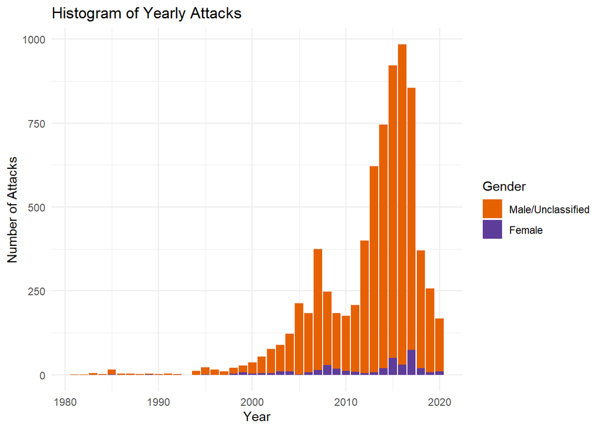

```r
# Bar plot
ggplot(d, aes(x = iyear, fill = female)) +
  geom_bar() +
  labs(
    x = "Year",
    y = "Number of Attacks",
    fill = "Gender",
    title = "Histogram of Yearly Attacks") +
  scale_fill_manual(
    values = c("0" = "#e66101", "1" = "#5e3c99"),
    labels = c("Male/Unclassified", "Female")) +
  theme_minimal()
```

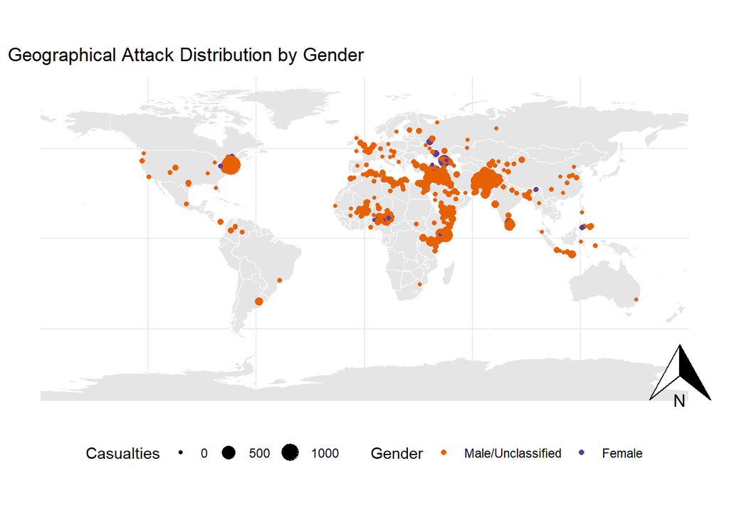

```r
# Map
d_clean <- d %>%
  filter(!is.na(longitude) & !is.na(latitude)) # Remove rows with NA in coordinates

d_map <- st_as_sf( # Converting clean df to sf object
  d_clean,
  coords = c("longitude", "latitude"),
  crs = 4326) # choosing EPSG:4326 as coordinate system

world <- ne_countries(scale = "medium", returnclass = "sf") # loading world map from naturalearth as sf object

ggplot() +
  geom_sf(data = world, fill = "gray90", color = "white") +
  geom_sf(data = d_map, aes(size = nkill, color = female)) +
  labs(
    title = "Geographical Attack Distribution by Gender",
    color = "Gender",
    size = "Casualties") +
  ggspatial::annotation_north_arrow(location = "br") +
  scale_color_manual(
    values = c("0" = "#e66101", "1" = "#5e3c99"),
    labels = c("Male/Unclassified", "Female")) +
  theme_minimal() +
  theme(
    legend.position = "bottom",
    legend.box = "horizontal")
```

Visually inspecting the data, it appears highly unbalanced. Recent years, male perpetrators, and certain geographical regions are over-represented.

## Visually inspecting for potential predictors of lethality

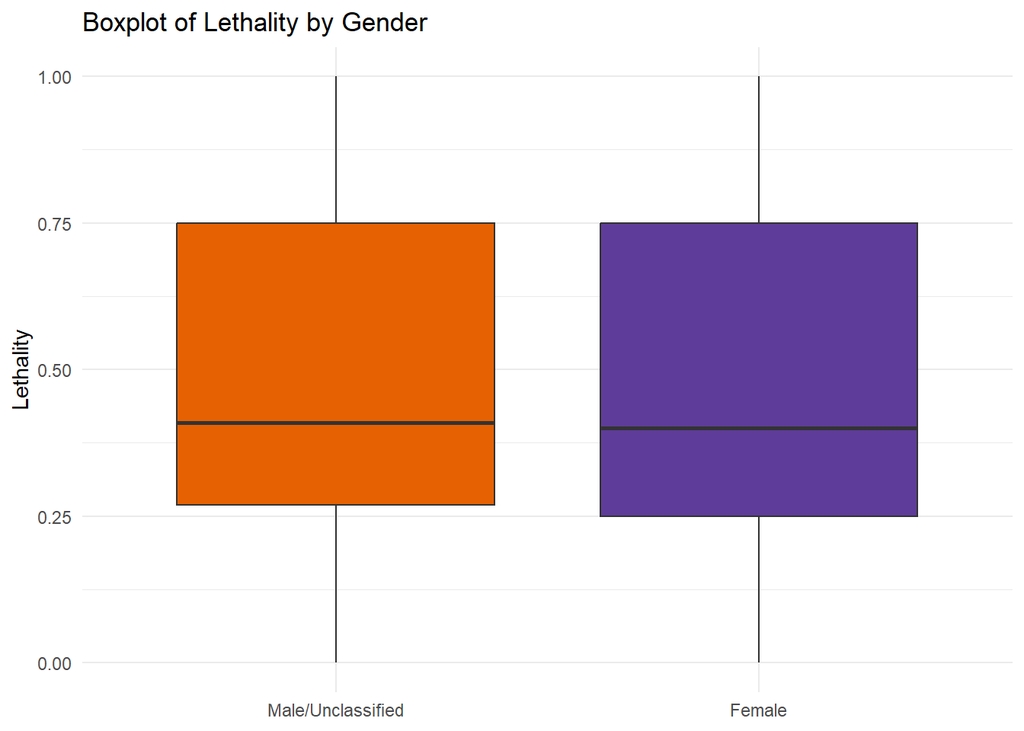

```r
# Box plot of gender
ggplot(d, aes(x = female, y = lethality, fill = female)) +
  geom_boxplot() +
  labs(
    x = NULL,
    y = "Lethality",
    title = "Boxplot of Lethality by Gender") +
  scale_fill_manual(
    values = c("0" = "#e66101", "1" = "#5e3c99"),
    labels = c("Male/Unclassified", "Female")) +
  scale_x_discrete(labels = c("0" = "Male/Unclassified", "1" = "Female")) +
  theme_minimal() +
  theme(legend.position = "none")
```

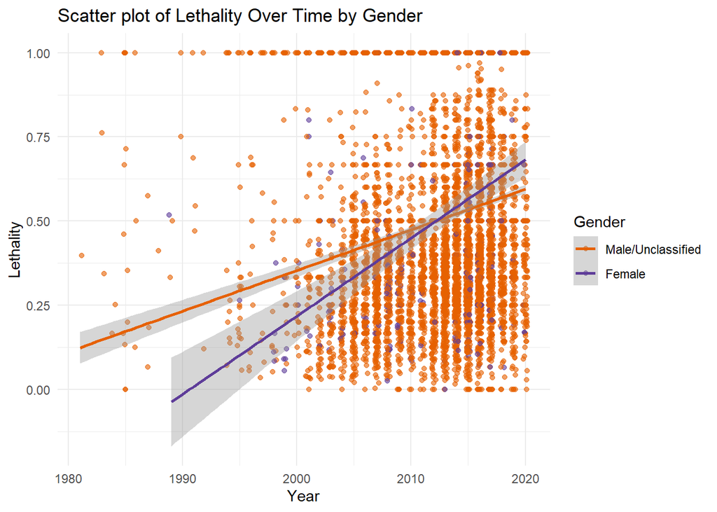

```r
# Scatter plot of year
ggplot(d, aes(iyear, lethality, col = female)) +
  geom_point(position = position_jitter(width = 0.2, height = 0), alpha = 0.6) +
  geom_smooth(method = "lm", se = TRUE) +
  labs(
    title = "Scatter plot of Lethality Over Time by Gender",
    x = "Year",
    y = "Lethality",
    color = "Gender") +
  scale_color_manual(
    values = c("0" = "#e66101", "1" = "#5e3c99"),
    labels = c("Male/Unclassified", "Female")) +
    theme_minimal()
```

Inspecting ‘gender’ alone, there is no visual difference in ‘lethality.’ However, when also introducing ‘year’, the scatter plot indicates that there could be a gender effect.

## Correlation testing for year-lethality relationship

```r
cor.test(d$iyear, d$lethality) # Running a correlation on year and lethality
```

```
##
##  Pearson's product-moment correlation
##
## data:  d$iyear and d$lethality
## t = 17.885, df = 6540, p-value < 2.2e-16
## alternative hypothesis: true correlation is not equal to 0
## 95 percent confidence interval:
##  0.1927133 0.2389207
## sample estimates:
##       cor
## 0.2159379
```

Judging from the correlation results, there is a weak but significant (p < .001) correlation between year and lethality.

## t-test for testing gender-lethality relationship (unequal mean lethality between genders)

```r
t.test(nkill ~ female, data = d, var.equal = FALSE) # using Welch's t-test because of unequal variances
```

```
##
##  Welch Two Sample t-test
##
## data:  nkill by female
## t = 1.1982, df = 431.95, p-value = 0.2315
## alternative hypothesis: true difference in means between group 0 and group 1 is not equal to 0
## 95 percent confidence interval:
##  -0.9250049  3.8142423
## sample estimates:
## mean in group 0 mean in group 1
##       10.212775        8.768156
```

```r
t.test(nkillwound ~ female, data = d, var.equal = FALSE)
```

```
##
##  Welch Two Sample t-test
##
## data:  nkillwound by female
## t = 0.78369, df = 814.61, p-value = 0.4334
## alternative hypothesis: true difference in means between group 0 and group 1 is not equal to 0
## 95 percent confidence interval:
##  -5.511753 12.837987
## sample estimates:
## mean in group 0 mean in group 1
##        31.10300        27.43988
```

```r
t.test(lethality ~ female, data = d, var.equal = FALSE)
```

```
##
##  Welch Two Sample t-test
##
## data:  lethality by female
## t = 0.27297, df = 351.51, p-value = 0.785
## alternative hypothesis: true difference in means between group 0 and group 1 is not equal to 0
## 95 percent confidence interval:
##  -0.03083812  0.04077815
## sample estimates:
## mean in group 0 mean in group 1
##       0.5064723       0.5015023
```

Neither of the lethality measures turned out to have significant different means between gender groups. Also, as I’m doing multiple t-tests, the threshold should actually be corrected for multiple comparisons anyways. This confirms my suspicion from the boxplot, that gender alone does not predict lethality.

## Fitting linear models with year, gender, and geographical region as predictors

```r
# transforming year variable to be zero-indexed for interpretability
d <- d %>%
  mutate(iyear_adj = iyear - 1970)

# Fitting models with increasing complexity
m1 <- lm(lethality ~ female, d)

m2 <- lm(lethality ~ female + region_txt, d)
m3 <- lm(lethality ~ female * region_txt, d)

m4 <- lm(lethality ~ iyear_adj + female, d)
m5 <- lm(lethality ~ iyear_adj + female + region_txt, d)
m6 <- lm(lethality ~ iyear_adj + female * region_txt, d)

# Comparing models
anova(m1, m2, m3, m4, m5, m6)
```

```
## Analysis of Variance Table
##
## Model 1: lethality ~ female
## Model 2: lethality ~ female + region_txt
## Model 3: lethality ~ female * region_txt
## Model 4: lethality ~ iyear_adj + female
## Model 5: lethality ~ iyear_adj + female + region_txt
## Model 6: lethality ~ iyear_adj + female * region_txt
##   Res.Df    RSS  Df Sum of Sq       F    Pr(>F)
## 1   6540 621.69
## 2   6530 612.51  10    9.1782 10.2538 < 2.2e-16 ***
## 3   6524 608.43   6    4.0746  7.5870 3.937e-08 ***
## 4   6539 592.71 -15   15.7290
## 5   6529 586.45  10    6.2552  6.9883 5.405e-11 ***
## 6   6523 583.87   6    2.5788  4.8016 6.768e-05 ***
## ---
## Signif. codes:  0 '***' 0.001 '**' 0.01 '*' 0.05 '.' 0.1 ' ' 1
```

```r
AIC(m1, m2, m3, m4, m5, m6)
```

```
##    df      AIC
## m1  3 3174.397
## m2 13 3097.095
## m3 19 3065.430
## m4  4 2864.085
## m5 14 2814.676
## m6 20 2797.846
```

Comparing the models, the most complex model appears to be the best. m6 is significantly better than the null model, and results in the lowest amount of error and also the lowest AIC-value.

## Inspecting model fit

Baseline indicates male (female = 0), year = 1970, and region = Australasia & Oceania.

```r
summary(m6)
```

```
##
## Call:
## lm(formula = lethality ~ iyear_adj + female * region_txt, data = d)
##
## Residuals:
##      Min       1Q   Median       3Q      Max
## -0.63328 -0.22881 -0.08402  0.23807  0.84116
##
## Coefficients: (4 not defined because of singularities)
##                                                Estimate Std. Error t value
## (Intercept)                                   0.7057141  0.2997086   2.355
## iyear_adj                                     0.0122619  0.0007402  16.566
## female1                                       0.0674967  0.0257801   2.618
## region_txtCentral Asia                       -0.6134332  0.3139782  -1.954
## region_txtEast Asia                          -0.7581983  0.3092110  -2.452
## region_txtEastern Europe                     -0.7397316  0.3014248  -2.454
## region_txtMiddle East & North Africa         -0.7062822  0.2995315  -2.358
## region_txtNorth America                      -0.6487439  0.3071262  -2.112
## region_txtSouth America                      -0.7977413  0.3174253  -2.513
## region_txtSouth Asia                         -0.7473593  0.2995718  -2.495
## region_txtSoutheast Asia                     -0.8957561  0.3032792  -2.954
## region_txtSub-Saharan Africa                 -0.7110429  0.2998374  -2.371
## region_txtWestern Europe                     -0.9367050  0.3041843  -3.079
## female1:region_txtCentral Asia               -0.3459134  0.3148672  -1.099
## female1:region_txtEast Asia                          NA         NA      NA
## female1:region_txtEastern Europe              0.0244397  0.0797335   0.307
## female1:region_txtMiddle East & North Africa -0.2076944  0.0425274  -4.884
## female1:region_txtNorth America              -0.0675955  0.2240071  -0.302
## female1:region_txtSouth America                      NA         NA      NA
## female1:region_txtSouth Asia                 -0.1160930  0.0521235  -2.227
## female1:region_txtSoutheast Asia             -0.3094958  0.1811781  -1.708
## female1:region_txtSub-Saharan Africa                 NA         NA      NA
## female1:region_txtWestern Europe                     NA         NA      NA
##                                              Pr(>|t|)
## (Intercept)                                   0.01857 *
## iyear_adj                                     < 2e-16 ***
## female1                                       0.00886 **
## region_txtCentral Asia                        0.05077 .
## region_txtEast Asia                           0.01423 *
## region_txtEastern Europe                      0.01415 *
```

[output cut: 9 more lines]

```
## female1:region_txtEastern Europe              0.75922
## female1:region_txtMiddle East & North Africa 1.07e-06 ***
## female1:region_txtNorth America               0.76285
## female1:region_txtSouth America                    NA
## female1:region_txtSouth Asia                  0.02596 *
## female1:region_txtSoutheast Asia              0.08764 .
## female1:region_txtSub-Saharan Africa               NA
## female1:region_txtWestern Europe                   NA
## ---
## Signif. codes:  0 '***' 0.001 '**' 0.01 '*' 0.05 '.' 0.1 ' ' 1
##
## Residual standard error: 0.2992 on 6523 degrees of freedom
##   (896 observations deleted due to missingness)
## Multiple R-squared:  0.06084,    Adjusted R-squared:  0.05825
## F-statistic: 23.48 on 18 and 6523 DF,  p-value: < 2.2e-16
```

## Visually presenting interaction effect of geopraphical region

```r
# manually creating df with interaction effects from m6
region_interaction <- data.frame(
  region = c("Central Asia", "East Asia", "Eastern Europe",
             "Middle East & North Africa", "North America",
             "South America", "South Asia", "Southeast Asia",
             "Sub-Saharan Africa", "Western Europe"),
  p_value = c(0.27198, NA, 0.75922, 1.07e-06, 0.76285,
              NA, 0.02596, 0.08764, NA, NA))

# making col with significant/not significant (alfa = .05)
region_interaction$significance <- ifelse(
  region_interaction$p_value < 0.05, "Significant", "Not Significant")
region_interaction$significance[is.na(region_interaction$p_value)] <- "Not Applicable" # primarily regions with too few entries

# preparing translation-table for regions before merging
region_mapping <- c(
  "Central Asia" = "Europe & Central Asia",
  "East Asia" = "East Asia & Pacific",
  "Eastern Europe" = "Europe & Central Asia",
  "Middle East & North Africa" = "Middle East & North Africa",
  "North America" = "North America",
  "South America" = "Latin America & Caribbean",
  "South Asia" = "South Asia",
  "Southeast Asia" = "East Asia & Pacific",
  "Sub-Saharan Africa" = "Sub-Saharan Africa",
  "Western Europe" = "Europe & Central Asia")

# applying translation-table to interaction output df
region_interaction$region_wb <- region_mapping[region_interaction$region]

# merging interaction output df with world df
world_with_significance <- world %>%
  left_join(region_interaction, by = c("region_wb" = "region_wb")) # defining to merge where this variable contains the same value
```

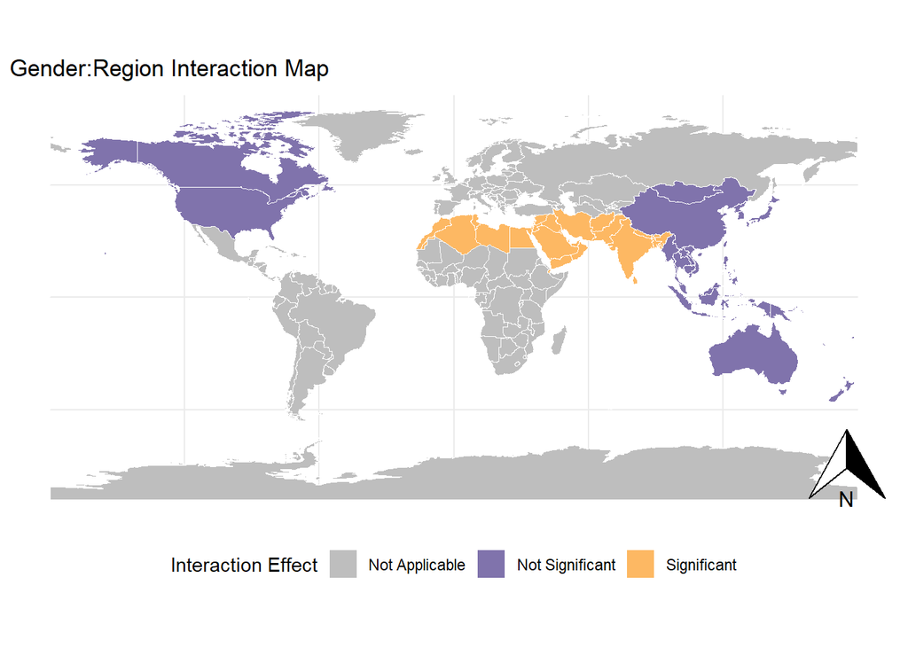

```r
# replacing NAs with "Not Applicable" in significance col
world_with_significance$significance <- replace_na(world_with_significance$significance, "Not Applicable")

# Map
ggplot() +
  geom_sf(data = world_with_significance, aes(fill = significance), color = "white") +
  labs(
    fill = "Interaction Effect",
    title = "Gender:Region Interaction Map") +
  scale_fill_manual(
    values = c("Significant" = "#fdb863", "Not Significant" = "#8073ac", "Not Applicable" = "gray"),
    na.translate = FALSE) +
  ggspatial::annotation_north_arrow(location = "br") +
  theme_minimal() +
  theme(
    legend.position = "bottom",
    legend.box = "horizontal")
```